# Observing Instagram clothing advertisement patterns

## Introduction

This data I collected analyses the frequency of different clothing advertisements on Instagram over a period of time. I collected this data by logging each individual observation into a Google form, this included details such as time of day observed, type of clothing advertised, main colour scheme, and if the ad was observed more than once in the same scrolling session. My aim for collecting this data was to create visualisations to interpret how different clothing ads are portrayed, and how often specific advertisements are shown. I was especially interested in the types of clothing ads that would be shown the most depending on the time of day.

## Sleepwear in comparison with other clothing advertisments

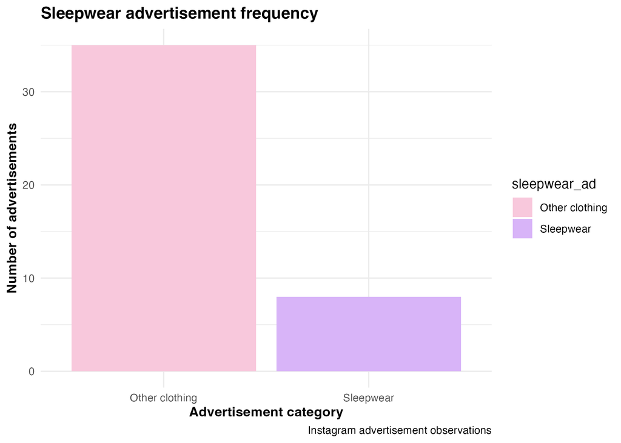

Bar chart comparing sleepwear advertisements with other clothing advertisements.

My first plot shows the frequency of sleepwear ads shown in comparison to all other clothing types. I identified sleepwear by the searches lounge, pyjama, pajama, and sleep. As shown in the plot above, sleepwear advertisements accounted for nearly a fifth of the total advertisements observed. This indicates that sleepwear was a relatively common advertisement to be exposed to. This could be dependent on time of day observed. In addition to this, it could also be influenced by my purchasing history, or what ads I tend to click on most on Instagram. Therefore, this could change depending on the individual and their purchasing habits. It would be interesting to further analyse sleepwear advertisements and see if their exposure frequency changes depending on the time of day. I would hypothesize that sleepwear ads would come across more frequently as the day gets later.

## Formal wear advertisments and time of day shown

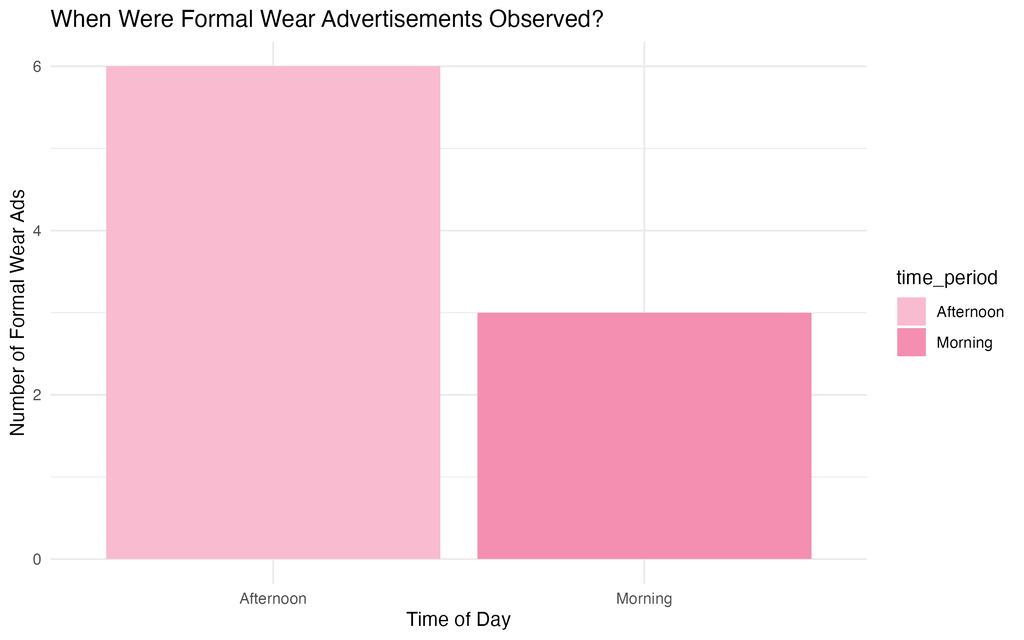

Bar chart showing formal wear advertisements across different times of day.

This plot showing formal wear advertisements indicates that it was more common for these types of advertisements to be observed later in the day (6 observed in afternoon versus 3 in the morning). This suggests that advertisements could be sensitive to time shown, as formal wear is most often worn at night. This suggests that ads could be shown at the time of day they are most commonly worn, for example formal wear and sleepwear ads being shown later in the day. However, to actually back this claim, I would have to research this further with a significantly higher amount of observations pertaining to formal wear advertisements and time of day. These observations would also have to take place over a substantial period of time. This observation may also be dependent on which times of the day I am most actively on social media, since I am much more likely to be exposed to a larger amount of ads the longer I am scrolling.

## Repeated advertisements by type of clothing

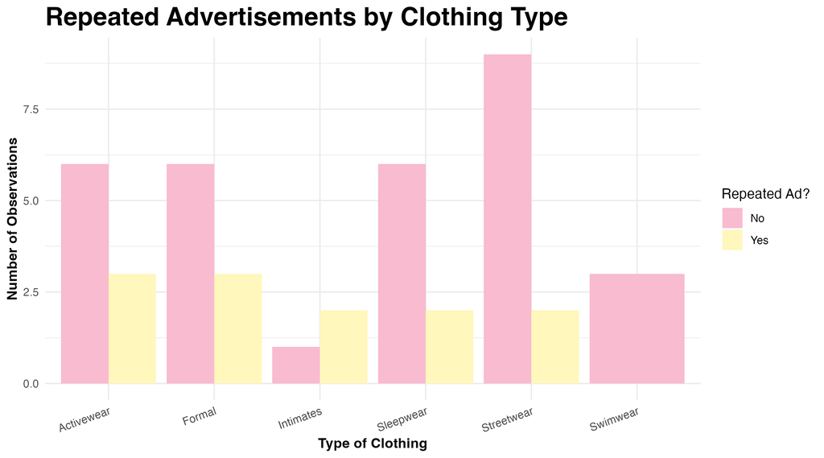

Grouped bar chart showing whether clothing advertisements were repeated during the same scrolling session.

My last visualisation observes whether the same advertisement was seen more than once within the same scrolling session. In the bar chart, I have grouped by clothing type. This makes it easier to compare results. Looking at the graph, we can observe that the only clothing ad not observed more than once was swim wear. This could be because there was a lower frequency of swimwear ads observed in general, or it could be because there is a larger number of swimwear companies advertising their products on Instagram. To further investigate this, I would have to focus on observing purely swimwear ads over a period of time.

## What the data collected suggests

Overall, these visualisations analyse how clothing advertisements on Instagram can be measured and observed in multiple different ways. This data focuses on what type of clothing was advertised, at what time of day, and if specific ads were repeated during the same scrolling session. Looking at this data visually helps to make sense of these patterns and convert these ads seen several times daily into something that can be statistically analysed. With the data collected, I can infer that clothing advertisements are not random, and instead can be influenced by an individual’s consumer behaviour, social media activity, and time of day. However, to claim an actual relationship between these variables, I would need to further explore this data with a substantial amount more of observations. I would also need to collect this data over a prolonged period of time to ensure that any potential biases are minimalised.